# Sessions 3-4

T. Evgeniou

The purpose of this session is to become familiar with:

1. Some visualization tools;
2. Principal Component Analysis and Factor Analysis;
3. Clustering Methods;
4. Introduction to machine learning methods;
5. A market segmentation case study.

As always, before starting, make sure you have pulled the [session 3-4 files](https://github.com/InseadDataAnalytics/INSEADAnalytics/tree/master/CourseSessions/Sessions23) (yes, I know, it says session 2, but it is 3-4 - need to update all filenames some time, but till then we use common sense and ignore a bit the filenames) on your github repository (if you pull the course github repository you also get the session files automatically). Moreover, make sure you are in the directory of this exercise. Directory paths may be complicated, and sometimes a frustrating source of problems, so it is recommended that you use these R commands to find out your current working directory and, if needed, set it where you have the main files for the specific exercise/project (there are other ways, but for now just be aware of this path issue). For example, assuming we are now in the “MYDIRECTORY/INSEADAnalytics” directory, we can do these:

```r
getwd()
setwd("CourseSessions/Sessions23")
list.files()
rm(list = ls())  # Clean up the memory, if we want to rerun from scratch
```

As always, you can use the `help` command in Rstudio to find out about any R function (e.g. type `help(list.files)` to learn what the R function `list.files` does).

Let’s start.

### Survey Data for Market Segmentation

We will be using the [boats case study](http://inseaddataanalytics.github.io/INSEADAnalytics/Boats-A-prerelease.pdf) as an example. At the end of this class we will be able to develop (from scratch) the readings of sessions 3-4 as well as understand the tools used and the interpretation of the results in practice - in order to make business decisions. The code used here is along the lines of the code in the session directory, e.g. in the RunStudy.R file and the report [doc/Report_s23.Rmd.](https://github.com/InseadDataAnalytics/INSEADAnalytics/blob/master/CourseSessions/Sessions23/doc/Report_s23.Rmd) There may be a few differences, as there are many ways to write code to do the same thing.

Let’s load the data:

```r
ProjectData <- read.csv("data/Boats.csv", sep = ";", dec = ",")  # this contains only the matrix ProjectData
ProjectData = data.matrix(ProjectData)
colnames(ProjectData) <- gsub("\\.", " ", colnames(ProjectData))
ProjectDataFactor = ProjectData[, c(2:30)]
```

#### Questions

##### Answers:

1. Yes and yes.
2. We don’t need all the question responses in our data analysis.

### Key Customer Attitudes

Clearly the survey asked many reduntant questions (can you think some reasons why?), so we may be able to actually “group” these 29 attitude questions into only a few “key factors”. This not only will simplify the data, but will also greatly facilitate our understanding of the customers.

To do so, we use methods called [Principal Component Analysis](https://en.wikipedia.org/wiki/Principal_component_analysis) and [factor analysis](https://en.wikipedia.org/wiki/Factor_analysis) as discussed in the [session readings](http://inseaddataanalytics.github.io/INSEADAnalytics/Report_s23.html). We can use two different R commands for this (they make slightly different information easily available as output): the command `principal` (check `help(principal)` from R package [psych](http://personality-project.org/r/psych/)), and the command `PCA` from R package [FactoMineR](http://factominer.free.fr) - there are more packages and commands for this, as these methods are very widely used.

Here is how the `principal` function is used:

```r
UnRotated_Results <- principal(ProjectDataFactor, nfactors = ncol(ProjectDataFactor),
    rotate = "none", score = TRUE)
UnRotated_Factors <- round(UnRotated_Results$loadings, 2)
UnRotated_Factors <- as.data.frame(unclass(UnRotated_Factors))
colnames(UnRotated_Factors) <- paste("Component", 1:ncol(UnRotated_Factors),
    sep = " ")
```

Here is how we use `PCA` one is used:

```r
Variance_Explained_Table_results <- PCA(ProjectDataFactor, graph = FALSE)
Variance_Explained_Table <- Variance_Explained_Table_results$eig
Variance_Explained_Table_copy <- Variance_Explained_Table
row = 1:nrow(Variance_Explained_Table)
name <- paste("Component No:", row, sep = "")
Variance_Explained_Table <- cbind(name, Variance_Explained_Table)
Variance_Explained_Table <- as.data.frame(Variance_Explained_Table)
colnames(Variance_Explained_Table) <- c("Components", "Eigenvalue", "Percentage_of_explained_variance",
    "Cumulative_percentage_of_explained_variance")

eigenvalues <- Variance_Explained_Table[, 2]
```

**Your Answers here:** 1. The percentage of variance explained by the components. We can use this to decided which components to included in our data analysis.  
2. It cannot be increasing because they should add up to 100. 3. The preference to see many components that expalin the variance in the data not just a handful.

#### Visualization and Interpretation

```r
# Choose one of these options:
factors_selected = sum(Variance_Explained_Table_copy[, 1] >= 1)
# minimum_variance_explained = 0.5; factors_selected =
# 1:head(which(Variance_Explained_Table_copy[,'cumulative percentage of
# variance']>= minimum_variance_explained),1) factors_selected = 10
```

To better visualise them, we will use what is called a “rotation”. There are many rotations methods, we use what is called the [varimax](http://stats.stackexchange.com/questions/612/is-pca-followed-by-a-rotation-such-as-varimax-still-pca) rotation:

```r
# Please ENTER the rotation eventually used (e.g. 'none', 'varimax',
# 'quatimax', 'promax', 'oblimin', 'simplimax', and 'cluster' - see
# help(principal)). Defauls is 'varimax'
rotation_used = "varimax"
```

```r
Rotated_Results <- principal(ProjectDataFactor, nfactors = max(factors_selected),
    rotate = rotation_used, score = TRUE)
Rotated_Factors <- round(Rotated_Results$loadings, 2)
Rotated_Factors <- as.data.frame(unclass(Rotated_Factors))
colnames(Rotated_Factors) <- paste("Component", 1:ncol(Rotated_Factors), sep = " ")
sorted_rows <- sort(Rotated_Factors[, 1], decreasing = TRUE, index.return = TRUE)$ix
Rotated_Factors <- Rotated_Factors[sorted_rows, ]
```

```r
MIN_VALUE = 0.5
Rotated_Factors_thres <- Rotated_Factors
Rotated_Factors_thres[abs(Rotated_Factors_thres) < MIN_VALUE] <- NA
colnames(Rotated_Factors_thres) <- colnames(Rotated_Factors)
rownames(Rotated_Factors_thres) <- rownames(Rotated_Factors)
```

#### Questions

1. What do the first couple of factors mean? Do they make business sense?
2. How many factors should we choose for this data/customer base?
3. How would you interpret the factors you selected?
4. What lessons about data science do you learn when doing this analysis?
5. (Extra) Can you make this report “dynamic” using shiny and then post it on shinyapps.io? (see for example exercise set 1)

**Your Answers here:** 1. status and experience. yes.  
2. 5 or more. 3. 3- brand. 4- reliability. 5- practicality 4. data sciense allows business managers to extract meaningful information from a bunch of numbers in a scientific way.

### Market Segmentation

Let’s now use one representative question for each factor (we can also use the “factor scores” for each respondent - see [session readings](http://inseaddataanalytics.github.io/INSEADAnalytics/Report_s23.html)) to represent our survey respondents. We can choose the question with the highest absolute factor loading for each factor. For example, when we use 5 factors with the varimax rotation we can select questions Q.1.9 (I see my boat as a status symbol), Q1.18 (Boating gives me a feeling of adventure), Q1.4 (I only consider buying a boat from a reputable brand), Q1.11 (I tend to perform minor boat repairs and maintenance on my own) and Q1.2 (When buying a boat getting the lowest price is more important than the boat brand) - try it. These are columns 10, 19, 5, 12, and 3, respectively of the data matrix `Projectdata`.

In market segmentation one may use variables to **profile** the segments which are not the same (necessarily) as those used to **segment** the market: the latter may be, for example, attitude/needs related (you define segments based on what the customers “need”), while the former may be any information that allows a company to identify the defined customer segments (e.g. demographics, location, etc). Of course deciding which variables to use for segmentation and which to use for profiling (and then **activation** of the segmentation for business purposes) is largely subjective. So in this case we will use all survey questions for profiling for now:

```r
segmentation_attributes_used = c(10, 19, 5, 12, 3)
profile_attributes_used = 2:ncol(ProjectData)
ProjectData_segment = ProjectData[, segmentation_attributes_used]
ProjectData_profile = ProjectData[, profile_attributes_used]
```

A key family of methods used for segmenation is what is called **clustering methods**. This is a very important problem in statistics and **machine learning**, used in all sorts of applications such as in [Amazon’s pioneer work on recommender systems](http://www.cs.umd.edu/~samir/498/Amazon-Recommendations.pdf). There are many *mathematical methods* for clustering. We will use two very standard methods, **hierarchical clustering** and **k-means**. While the “math” behind all these methods can be complex, the R functions used are relatively simple to use, as we will see.

For example, to use hierarchical clustering we simply first define some parameters used (see session readings) and then simply call the command `hclust`:

```r
# Please ENTER the distance metric eventually used for the clustering in
# case of hierarchical clustering (e.g. 'euclidean', 'maximum', 'manhattan',
# 'canberra', 'binary' or 'minkowski' - see help(dist)).  DEFAULT is
# 'euclidean'
distance_used = "euclidean"
# Please ENTER the hierarchical clustering method to use (options are:
# 'ward', 'single', 'complete', 'average', 'mcquitty', 'median' or
# 'centroid') DEFAULT is 'ward.D'
hclust_method = "ward.D"
# Define the number of clusters:
numb_clusters_used = 3
```

```r
Hierarchical_Cluster_distances <- dist(ProjectData_segment, method = distance_used)
Hierarchical_Cluster <- hclust(Hierarchical_Cluster_distances, method = hclust_method)

# Assign observations (e.g. people) in their clusters
cluster_memberships_hclust <- as.vector(cutree(Hierarchical_Cluster, k = numb_clusters_used))
cluster_ids_hclust = unique(cluster_memberships_hclust)
ProjectData_with_hclust_membership <- cbind(1:length(cluster_memberships_hclust),
    cluster_memberships_hclust)
colnames(ProjectData_with_hclust_membership) <- c("Observation Number", "Cluster_Membership")
```

Finally, we can see the **dendrogram** (see class readings and online resources for more information) to have a first rough idea of what segments (clusters) we may have - and how many.

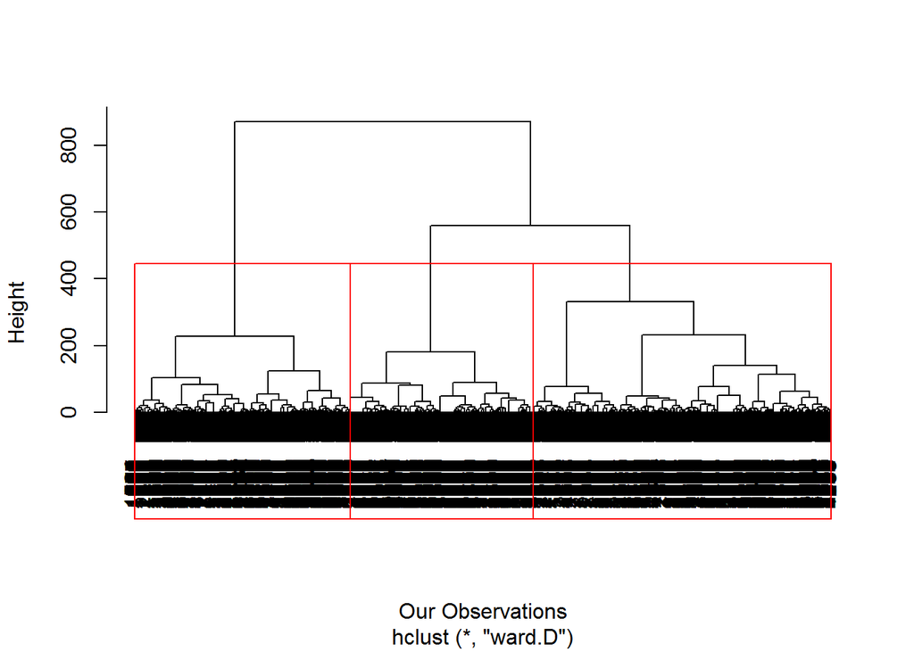

To use k-means on the other hand one needs to define a priori the number of segments (which of course one can change and re-cluster). K-means also requires the choice of a few more parameters, but this is beyond our scope for now. Here is how to run K-means:

```r
# Please ENTER the kmeans clustering method to use (options are:
# 'Hartigan-Wong', 'Lloyd', 'Forgy', 'MacQueen' DEFAULT is 'Lloyd'
kmeans_method = "Lloyd"
# Define the number of clusters:
numb_clusters_used = 3
kmeans_clusters <- kmeans(ProjectData_segment, centers = numb_clusters_used,
    iter.max = 2000, algorithm = kmeans_method)
ProjectData_with_kmeans_membership <- cbind(1:length(kmeans_clusters$cluster),
    kmeans_clusters$cluster)
colnames(ProjectData_with_kmeans_membership) <- c("Observation Number", "Cluster_Membership")

# Assign observations (e.g. people) in their clusters
cluster_memberships_kmeans <- kmeans_clusters$cluster
cluster_ids_kmeans <- unique(cluster_memberships_kmeans)
```

K-means does not provide much information about segmentation. However, when we profile the segments we can start getting a better (business) understanding of what is happening. **Profiling** is a central part of segmentation: this is where we really get to mix technical and business creativity.

### Profiling

There are many ways to do the profiling of the segments. For example, here we show how the *average* answers of the respondents *in each segment* compare to the *average answer of all respondents* using the ratio of the two. The idea is that if in a segment the average response to a question is very different (e.g. away from ratio of 1) than the overall average, then that question may indicate something about the segment relative to the total population.

```r
# Select whether to use the Hhierarchical clustering or the k-means
# clusters:

cluster_memberships <- cluster_memberships_hclust
cluster_ids <- cluster_ids_hclust
# here is the k-means: uncomment these 2 lines cluster_memberships <-
# cluster_memberships_kmeans cluster_ids <- cluster_ids_kmeans

population_average = matrix(apply(ProjectData_profile, 2, mean), ncol = 1)
colnames(population_average) <- "Population"
Cluster_Profile_mean <- sapply(sort(cluster_ids), function(i) apply(ProjectData_profile[(cluster_memberships ==
    i), ], 2, mean))
if (ncol(ProjectData_profile) < 2) Cluster_Profile_mean = t(Cluster_Profile_mean)
colnames(Cluster_Profile_mean) <- paste("Segment", 1:length(cluster_ids), sep = " ")
cluster.profile <- cbind(population_average, Cluster_Profile_mean)
```

```r
ratio_limit = 0.1
```

```r
population_average_matrix <- population_average[, "Population", drop = F] %*%
    matrix(rep(1, ncol(Cluster_Profile_mean)), nrow = 1)
cluster_profile_ratios <- (ifelse(population_average_matrix == 0, 0, Cluster_Profile_mean/population_average_matrix))
colnames(cluster_profile_ratios) <- paste("Segment", 1:ncol(cluster_profile_ratios),
    sep = " ")
rownames(cluster_profile_ratios) <- colnames(ProjectData)[profile_attributes_used]
## printing the result in a clean-slate table
```

```r
# Save the segment profiles in a file: enter the name of the file!
profile_file = "my_segmentation_profiles.csv"
write.csv(cluster_profile_ratios, file = profile_file)
# We can also save the cluster membership of our respondents:
data_with_segment_membership = cbind(cluster_memberships, ProjectData)
colnames(data_with_segment_membership)[1] = "Segment"
cluster_file = "my_segments.csv"
write.csv(data_with_segment_membership, file = cluster_file)
```

**The further a ratio is from 1, the more important that attribute is for a segment relative to the total population.**

#### Questions

1. How many segments are there in our market?
2. Can you describe the segments you found based on the profiles?
3. What if you change the number of factors and in general you “iterate the analysis”? **Iterations** are key in data science.
4. Can you now answer the [Boats case questions](http://inseaddataanalytics.github.io/INSEADAnalytics/Boats-A-prerelease.pdf)? What business decisions do you recommend to this company based on your analysis?

**Your Answers here:** 1. 3 segments or more.  
2. seg1-advanced/influencer; seg2-rich; seg3-adventurous/influencer.  
3. I could include more segments in the analysis.  
4. This is just one peice of the data we can use for decision making. it’s better to have more context before we make business recommendations.

**You have now completed your first market segmentation project.** Do you have data from another survey you can use with this report now?

**Extra question**: explore and report a new segmentation analysis…

… and as always **Have Fun**